# output: html_document

## Data Analysis

```
## [1] "US20, 3 Mi W of Santiam Pass Summit, Delay &lt; 20min, A crash has occurred, use caution.."
## [2] "US20, Santiam Pass Summit, Delay &lt; 20min, A crash has occurred, use caution.... http://"
## [3] "US20, 2 Mi W of Santiam Pass Summit, Delay &lt; 20min, A crash has occurred, use caution.."
## [4] "US20, 2 Mi W of Santiam Pass Summit, Delay &lt; 20min, A crash has occurred, use caution.."
## [5] "US20, 3 Mi E of Santiam Pass Summit, Delay &lt; 20min, A crash has occurred, use caution.."
## [6] "US20, 5 Mi W of Santiam Pass Summit, Delay &lt; 20min, A crash has occurred, use caution.."
```

```
## [1] "US20, santiam pass smt, Slush or snow pack, Carry chains/Tra"
## [2] "US20, santiam pass smt, Packed snow, Carry chains/Traction t"
## [3] "US20, tombstone, Packed snow, Carry chains/Traction tires..."
## [4] "US20, santiam pass smt, Slush or snow pack, Carry chains/Tra"
## [5] "US20, santiam pass smt, Slush or snow pack, Carry chains/Tra"
## [6] "US20, santiam pass smt, Slush or snow pack, Carry chains/Tra"
```

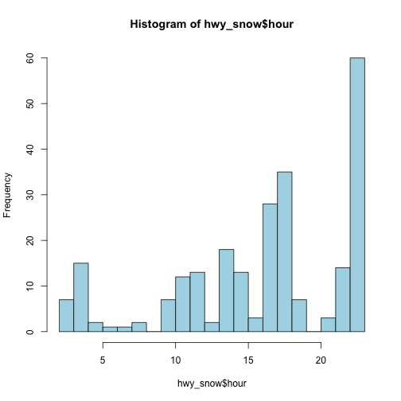

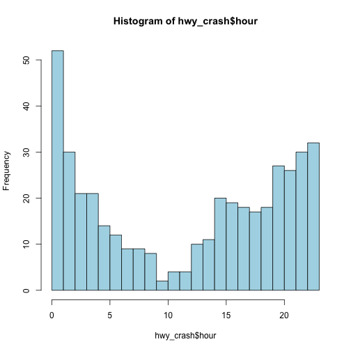

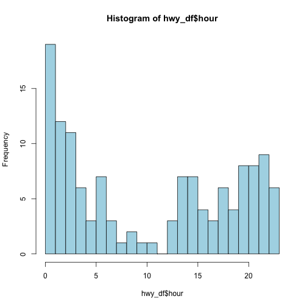

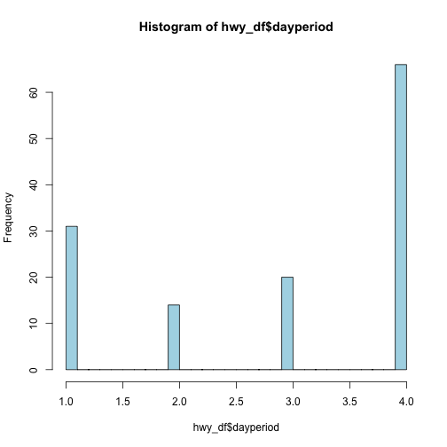

###Data analysis and reduction

To analyze the data create a dataframe of dates from 2014-12-08 to 2012-02-26 and then add two binary columns, one for whether a crash occured that day and whether snow was reported on the road. A few rows of the dataframe are shown.

####Weekend

```
##
##    Friday    Monday  Saturday    Sunday  Thursday   Tuesday Wednesday
##        31        17        24        16         9        14         9
```

####Model features

```
##           date Accident Snow   weekday wkend
## 600 2013-04-18        0    0  Thursday     0
## 601 2013-04-17        1    0 Wednesday     0
## 602 2013-04-16        1    1   Tuesday     0
## 603 2013-04-15        1    1    Monday     0
## 604 2013-04-14        0    1    Sunday     0
## 605 2013-04-13        1    1  Saturday     1
## 606 2013-04-12        0    0    Friday     1
## 607 2013-04-11        0    0  Thursday     0
## 608 2013-04-10        0    0 Wednesday     0
## 609 2013-04-09        0    0   Tuesday     0
## 610 2013-04-08        1    1    Monday     0
## 611 2013-04-07        1    1    Sunday     0
## 612 2013-04-06        0    1  Saturday     1
## 613 2013-04-05        1    0    Friday     1
## 614 2013-04-04        0    0  Thursday     0
## 615 2013-04-03        0    0 Wednesday     0
```

Per this analysis in a period of 1017 days there were:  
• 131 accidents  
• 243 days with snow  
• 66 days with snow and accidents

###Estimating Probabilities

The specific rates can be derived from above:  
p<sub>Acc</sub> = 0.129 per day.  
p<sub>Snow</sub> = 0.239 per day.  
p<sub>SnowAcc</sub> = 0.065 per day.

From these the conditional probabilities can be derived.

p(Acc|Snow) = p<sub>SnowAcc</sub> / p<sub>Snow</sub> = 0.272

and

p(Snow|Acc) = p<sub>SnowAcc</sub> / p<sub>Acc</sub> = 0.504

Hence, the odds that an accident occurs on Santiam pass if snow is reported is 0.37:1, which are about half.

The probability an accident occured given there was no snow is

p(Acc|Snow) = (p<sub>Acc</sub> - p(Acc|Snow))/(1 - p<sub>Snow</sub>) = 0.08

which implies odd of 0.087:1 or one about one chance in 12.

###Logistic Regression

We can use logistic regression to check odds

###Odd ratios for the model

```
##                     OR      2.5 %    97.5 %
## (Intercept) 0.05108857 0.03572631 0.0710266
## Snow        5.36913760 3.58657216 8.0880039
## wkend       2.70467633 1.79197511 4.0843175
```

Hence according to the regression model 5.37 is the increase in odds from no snow to snow.

Need to think about this one a bit…

###Time of Day

To look for correations with time of day need to simplify data to include only days with crashes (since it makes no sense to include a time of day for a day with no crash)

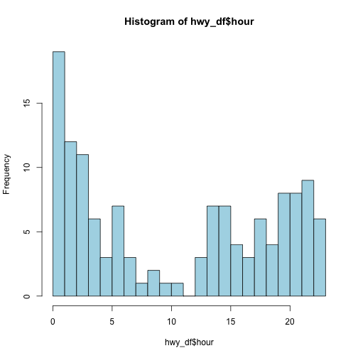

```r
require(ggplot2)
hist(hwy_df$hour, breaks = 24, col="lightblue")
```

```r
#tt<-hwy_df[hwy_df$hour<2|hwy_df$hour>4,]
#tt[1:30, c("created", "text", "hour", "hourdelta")]
```

###Conclusions

A next step in this anlaysis will be to use additional data features to improve prediction.